# Proyecto Final Diplomado Big Data para Políticas Públicas Universidad Adolfo Ibañez

27 de abril de 2018

# El equipo

| Nombre | Lugar de Trabajo | Cargo en el proyecto |
| --- | --- | --- |
| Priscila Rodríguez | Comisión Nacional de Energía | Jefa de Proyecto |
| Kiumarz Goharriz | Comisión Nacional de Energía | Visualización de Datos |
| Nicolás Torrealba | FOSIS | Científico y Analista de Datos |
| Eduardo Jimenez | Ministerio de Economía | Científico y Analista de Datos |

# Contexto

Durante los últimos años, si bien el número de causas no contenciosas que el TDLC ha debido analizar no ha variado significativamente, si lo ha hecho el impacto mediático de sus sentencias, toda vez que las mismas han afectado de distinta forma la vida de las personas. Casos emblemáticos como la colusión de las tres principales cadenas de farmacias en el precio de 220 medicamentos (2009), la colusión en el precio de los compresores de los refrigeradores entre Whirpool y su competidora Tecumseh (2012), la colusión de seis importantes navieras en el proceso de contratación de transporte marítimo de automóviles (aún en análisis) o bien, los famosos casos de colusión del mercado de los pollos, supermercados, confort y pañales, dan luces de la relevancia del impacto de las sentencias de este organismo en la sociedad.

No obstante, a pesar de la importancia de las decisiones del TDLC, no existen dentro de la página web del organismo módulos de visualización, que permitan de manera rápida tener una primera mirada de los mercados que son analizados con mayor frecuencia, las materias más relevantes, ni el número de veces en que el TDLC acoge o rechaza las solicitudes de los denunciantes en las causas no contenciosas, entre otros. En este sentido, el primer objetivo de este proyecto de data science, es que todos aquellos interesados en la información que emite este organismo regulador, puedan visualizar de forma rápida e ilustrativa, las estadísticas más relevantes, para lo cual se propone crear una plataforma con Shiny.

El segundo objetivo, pensando en el corto plazo, es analizar en profundidad los actos resolutorios del tribunal, para entender si existen patrones de comportamiento por parte del TDLC hasta el momento. Para esto se han tanteado algunos modelos que permitan realizar un buen ajuste y sacar a la luz características subyacentes.

Y finalmente, Un tercer objetivo, mucho más ambicioso por cierto y que va más allá de lo que se presentará hoy, es poder predecir en base a los expedientes de las causas no contenciosas de los último diez años, la probabilidad de que una nueva causa se acepte o se rechace.

# Preguntas de negocio

¿Podemos, en base a la información disponible de las causas no contenciosas del TDLC, en primer lugar, presentar la información de manera más informativa y, en segundo lugar, encontrar patrones de comportamiento dentro de los actos resolutorios que emite ? ¿Por qué nos interesa esto?

Primero, porque queremos algo más práctico que esto: http://www.tdlc.cl/tdlc/wp-content/uploads/Estadisticas/31marzo2017/No-Contenciosas-Mercados.pdf.

Y segundo: Porque queremos vender nuestra idea a un estudio de abogados y ser millonarios

# Datos utilizados

Para este proyecto, se descargaron desde la página del Tribunal de Defensa de la Libre Competencia, todos aquellos archivos .pdf clasificados dentro de la jurisprudencia como: instrucciones de carácter general, informes y resoluciones de las causas no contenciosas. Las recomendaciones normativas, al estar tangencialmente relacionadas con las causas no contenciosas quedaron fuera de la descarga.

# Ruta del proyecto

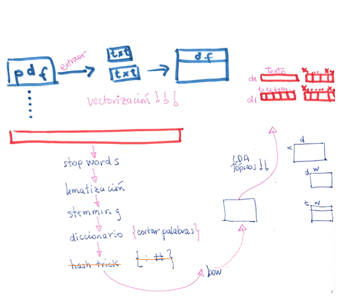